# AMA LAB 8 : Interpretability and Explainability in Machine Learning

### Model for out-of-bag importance measure

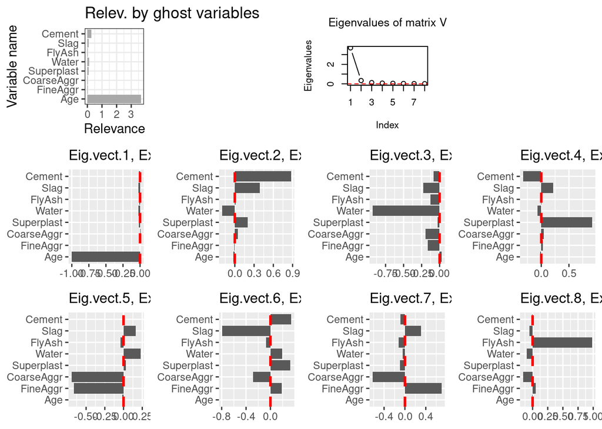

```r
Rel_Gh_Var.rf_oob <- relev.ghost.var(model=rf_oob,
                              newdata = concrete_test[, -9],
                              y.ts = concrete_test[, 9],
                              func.model.ghost.var = lm,
                              isRanger=TRUE)

plot.relev.ghost.var(Rel_Gh_Var.rf_oob,n1=330,ncols.plot = 4)
```

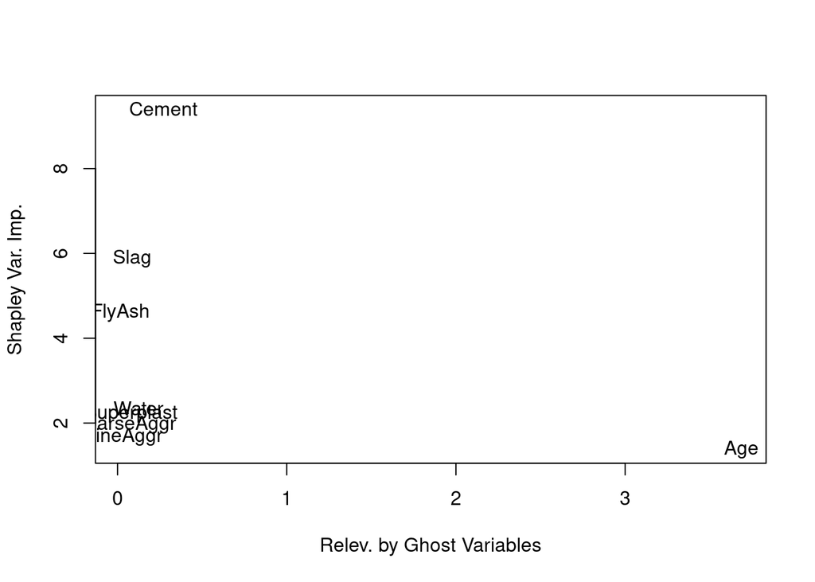

```r
aux <- cbind(Rel_Gh_Var.rf_oob$relev.ghost,rf_oob_shapley$data$Importance)
plot(aux[,1],aux[,2],col=0,xlab="Relev. by Ghost Variables",ylab="Shapley Var. Imp.")
text(aux[,1],aux[,2],row.names(aux))
```

Lastly in this plot we can see the ghost varaibles for the random forest out-of-bag, we can see that the most important variable in the is model is Age, and we can also see that the most important eigenvactor is the first eigenvector, in which age has a negative contribution to the model.

# 4. Global importance measures and plots using the library DALEX:

```r
explainer_rf <- explain.default(model = rf_impurity,
                               data = concrete_test[,-9],
                               y = concrete_test[,9],
                               label = "Random Forest")
```

```
## Preparation of a new explainer is initiated
##   -> model label       :  Random Forest
##   -> data              :  330  rows  8  cols
##   -> target variable   :  330  values
##   -> predict function  :  yhat.ranger  will be used (  default  )
##   -> predicted values  :  No value for predict function target column. (  default  )
##   -> model_info        :  package ranger , ver. 0.16.0 , task regression (  default  )
##   -> predicted values  :  numerical, min =  8.84077 , mean =  35.0511 , max =  75.49129
##   -> residual function :  difference between y and yhat (  default  )
##   -> residuals         :  numerical, min =  -21.6863 , mean =  -0.1415904 , max =  24.57344
##   A new explainer has been created!
```

## a) Compute Variable Importance by Random Permutations

```r
(Rnd_Perm <- model_parts(
  explainer_rf,
  N = NULL,
  B = 10
))
```

```
##        variable mean_dropout_loss         label
## 1  _full_model_          5.539260 Random Forest
## 2        FlyAsh          6.230918 Random Forest
## 3    CoarseAggr          6.242682 Random Forest
## 4      FineAggr          6.811660 Random Forest
## 5          Slag          6.848662 Random Forest
## 6    Superplast          7.280253 Random Forest
## 7         Water          9.048319 Random Forest
## 8        Cement         10.916006 Random Forest
## 9           Age         14.045019 Random Forest
## 10   _baseline_         21.663365 Random Forest
```

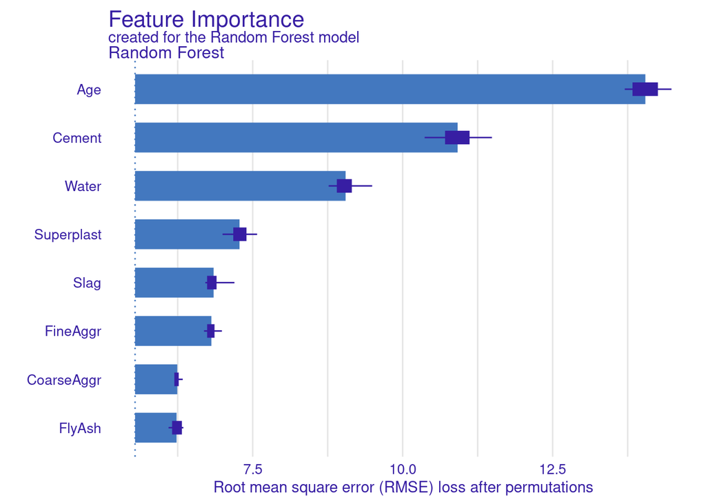

```r
plot(Rnd_Perm)
```

In this plot we can see the random permutation plot. At first glance, we can see that the most important variable is the Age which has a RMSE of around 14, followed by cement, and water. This means that when the Age, Cement and water variable are used the model will be the most accurate. On the other hand, when the model uses other variables like FlyAsh, CoarseAggr and FineAggr, the model will be the least accurate.

## b) Do the Partial Dependence Plot for each explanatory variable

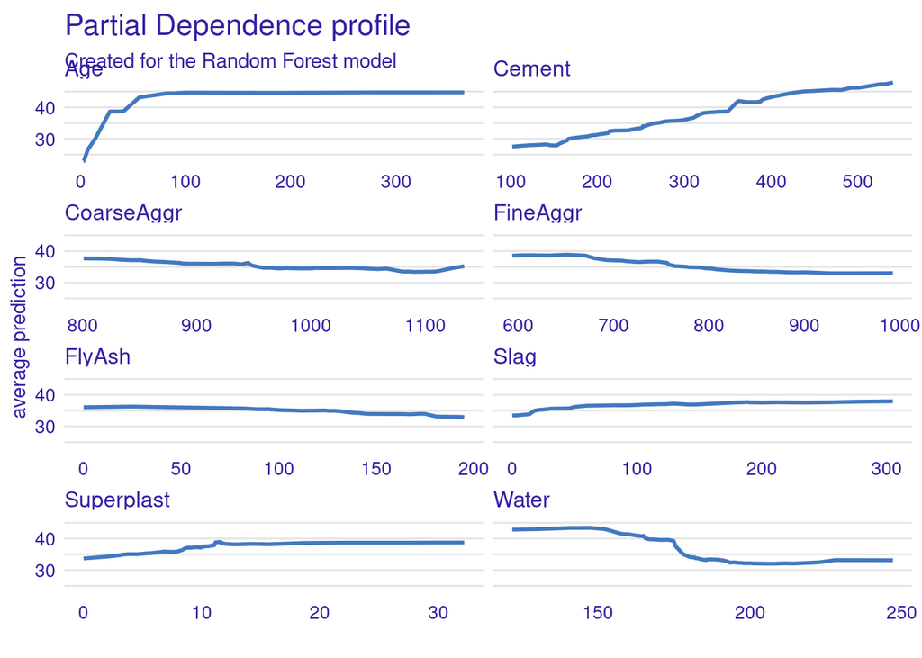

```r
PDP_rf <- model_profile(
  explainer=explainer_rf,
  variables = NULL, N = NULL,
  groups = NULL, k = NULL,
  center = TRUE, type = "partial")

plot(PDP_rf, facet_ncol=2)
```

For the partial dependence plot each explanatory varaible. First regading the Age, we can see that the strength of the concrete will be most affected on th early years until the 100, form then on it saturates and stays the same. Next, looking at the cement, we can see there is a steady increase as the cement content increases, so the more cement there is the stronger the concrete will be. Moving on to the CoarseAggr we can see a slow decrease in the cement strength to the point of almost stopping at around 1000 to 1100. Next we have FineAggr, here we can again see a decrease in the strength of the concrete as the fineaggr increases, we can see that at the beging, from the 600 to the 700 it’s not affected, but from there on the strength decreases. Then we have FlyAsh, and we can see how the strength again decreases slowly as the amount of FlyAsh increases. Looking now at the slag, can see a very slight increase in the strength of the concrete we can see that the strength has the most increase at the beginning, form 0 to around 25, form there on it stays almost the same. Then we have superplast that has a slow increase in the initial values, form 0 to 10, and form there on it stay almost the same. Last but not least, we have water, which have a steady state until the 150 value, and the decreases drastically in until the 200, and then stays the same until the 250. In the end, we can see the most change in the strngth in the age, cement, and water variables, this being in the end the most important ones.

## c) Do the Local (or Conditional) Dependence Plot for each explanatory variable.

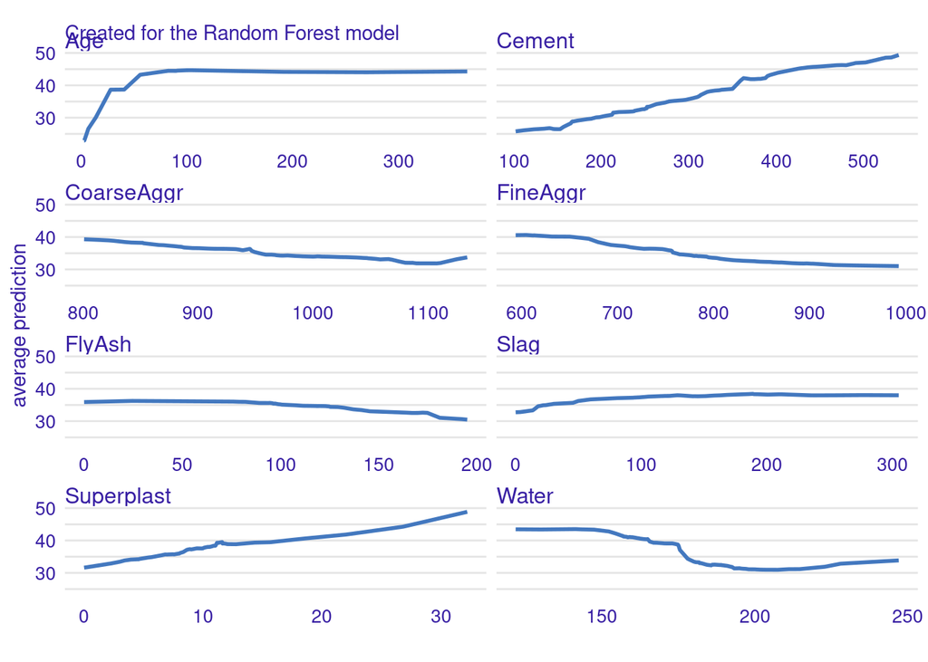

```r
CDP_rf <- model_profile(
  explainer=explainer_rf,
  variables = NULL,  N = NULL,
  groups = NULL, k = NULL,
  center = TRUE, type = "conditional")

plot(CDP_rf, facet_ncol=2)
```

# 5. Local explainers with library DALEX

We get the lowest and the highest strength values from the test set:

```r
(lowestStrength <- concrete_test[which.min(concrete_test$Strength),])
```

```
##     Cement Slag FlyAsh Water Superplast CoarseAggr FineAggr Age Strength
## 669    153  102      0   192          0        888    943.1   3 4.782206
```

```r
(highestStrength <- concrete_test[which.max(concrete_test$Strength),])
```

```
##     Cement  Slag FlyAsh Water Superplast CoarseAggr FineAggr Age Strength
## 154  323.7 282.8      0 183.8       10.3      942.7    659.9  56 80.19985
```

## a) Explain the predictions using SHAP:

```r
(bd_rf_lowest <- predict_parts(explainer = explainer_rf,
                 new_observation = lowestStrength,
                            type = "shap"))
```

```
##                                         min           q1      median
## Random Forest: Age = 3          -13.1900721 -11.91956355 -10.8623845
## Random Forest: Cement = 153      -8.4534497  -7.13310215  -6.4340130
## Random Forest: CoarseAggr = 888  -1.2299137  -0.01755739   0.2631119
## Random Forest: FineAggr = 943.1  -4.8001195  -3.33647372  -2.8584300
## Random Forest: FlyAsh = 0        -0.7315557   0.01902556   0.6416243
## Random Forest: Slag = 102        -0.1485253   0.29543986   0.9010904
## Random Forest: Superplast = 0    -4.0202684  -2.80762551  -1.8580848
## Random Forest: Water = 192       -4.7215833  -4.49254725  -3.8976479
##                                        mean         q3       max
## Random Forest: Age = 3          -10.8914847 -9.5009264 -9.059526
## Random Forest: Cement = 153      -6.4349157 -6.0360828 -4.446289
## Random Forest: CoarseAggr = 888   0.2630769  0.8008527  1.258074
## Random Forest: FineAggr = 943.1  -2.9105408 -2.3762999 -1.659684
## Random Forest: FlyAsh = 0         0.4025018  0.9851764  1.135370
## Random Forest: Slag = 102         0.8474576  1.5240519  1.798614
## Random Forest: Superplast = 0    -2.1471837 -1.3623781 -1.010710
## Random Forest: Water = 192       -3.7210319 -2.9793102 -1.711143
```

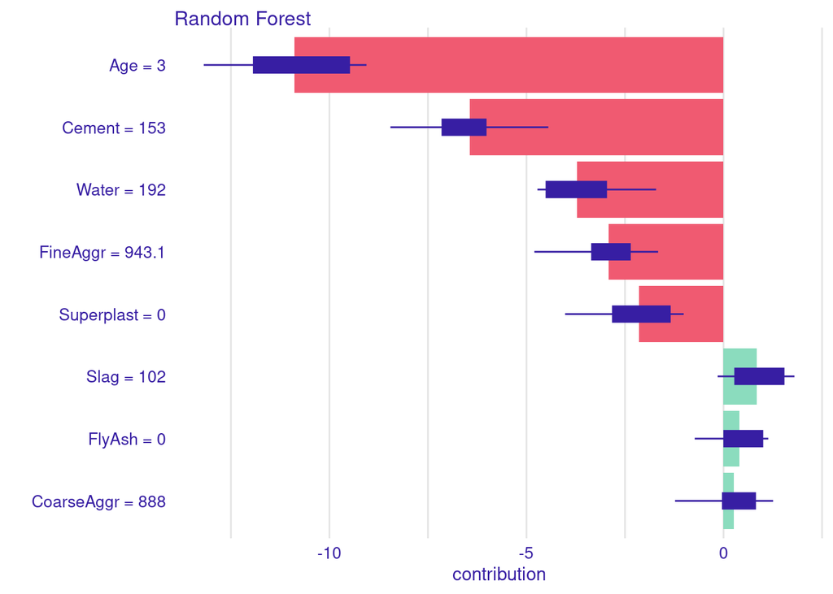

```r
plot(bd_rf_lowest)
```

```r
(bd_rf_highest <- predict_parts(explainer = explainer_rf,
                 new_observation = highestStrength,
                            type = "shap"))
```

```
##                                          min         q1     median      mean
## Random Forest: Age = 56            6.1425064  7.0893273  7.6435706  7.459146
## Random Forest: Cement = 323.7      3.1518345  3.6840993  4.2876662  4.589089
## Random Forest: CoarseAggr = 942.7  0.5616261  0.9954567  1.2461173  1.609096
## Random Forest: FineAggr = 659.9    1.7195043  2.6695398  3.2134262  3.033480
## Random Forest: FlyAsh = 0          0.5971740  1.0124361  1.2155425  1.230485
## Random Forest: Slag = 282.8        2.6256713  3.0862162  4.1106791  4.110072
## Random Forest: Superplast = 10.3   1.7815123  2.5463485  3.1617924  3.323065
## Random Forest: Water = 183.8      -2.1259218 -1.4920458 -0.8103649 -0.695065
##                                           q3       max
## Random Forest: Age = 56            7.9283003 8.2118776
## Random Forest: Cement = 323.7      5.1751158 6.7909998
## Random Forest: CoarseAggr = 942.7  2.0853464 3.3216961
## Random Forest: FineAggr = 659.9    3.3531315 4.6401845
## Random Forest: FlyAsh = 0          1.5767762 1.7865409
## Random Forest: Slag = 282.8        5.3260032 5.7304895
## Random Forest: Superplast = 10.3   3.6143553 5.7240992
## Random Forest: Water = 183.8      -0.1635871 0.8809817
```

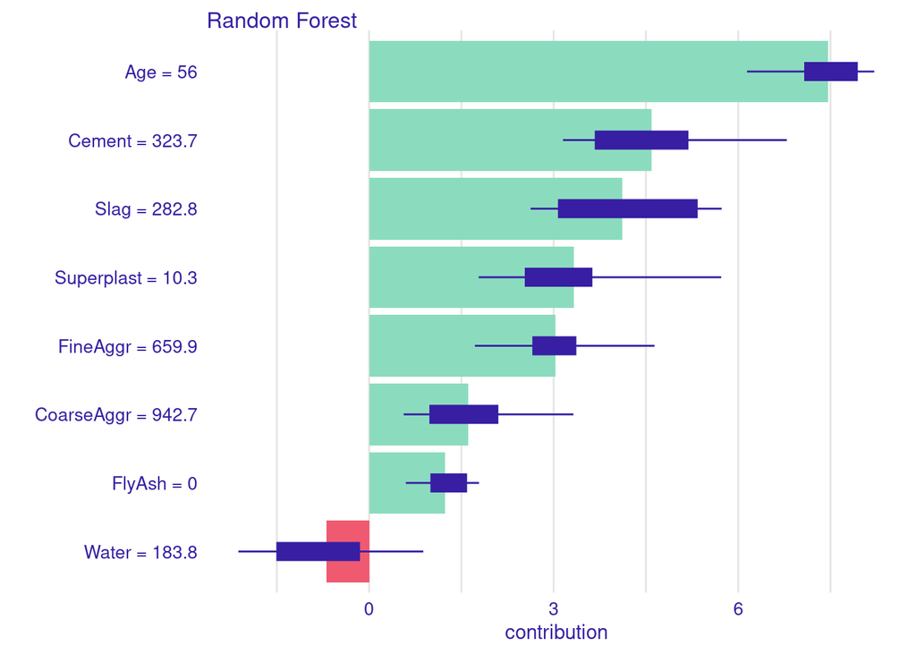

```r
plot(bd_rf_highest)
```

## b) Explain the predictions using Break-down plots:

```r
(bdown_rf_lowest <- predict_parts(explainer = explainer_rf,
                 new_observation = lowestStrength,
                            type = "break_down"))
```

```
##                                 contribution
## Random Forest: intercept              35.051
## Random Forest: Age = 3               -12.086
## Random Forest: Cement = 153           -4.446
## Random Forest: Water = 192            -2.004
## Random Forest: FineAggr = 943.1       -1.982
## Random Forest: Slag = 102              0.391
## Random Forest: Superplast = 0         -3.042
## Random Forest: FlyAsh = 0             -0.710
## Random Forest: CoarseAggr = 888       -0.714
## Random Forest: prediction             10.459
```

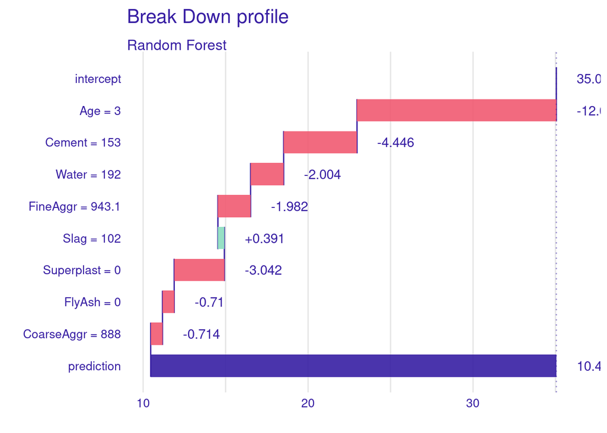

```r
plot(bdown_rf_lowest)
```

Here we can see the break-down plot for the lowest concrete strength, we can see also that almost none of the variables is making the prediction value increase, all of them are contributing negatively except for Slag that has a litte positve contribution. The variables that contribute the most negatively are Age, cement and superplast.

```r
(bdown_rf_highest <- predict_parts(explainer = explainer_rf,
                 new_observation = highestStrength,
                            type = "break_down"))
```

```
##                                   contribution
## Random Forest: intercept                35.051
## Random Forest: Age = 56                  8.107
## Random Forest: FineAggr = 659.9          3.482
## Random Forest: Cement = 323.7            2.661
## Random Forest: Slag = 282.8              2.196
## Random Forest: Superplast = 10.3         3.423
## Random Forest: Water = 183.8             0.033
## Random Forest: FlyAsh = 0                1.436
## Random Forest: CoarseAggr = 942.7        3.322
## Random Forest: prediction               59.710
```

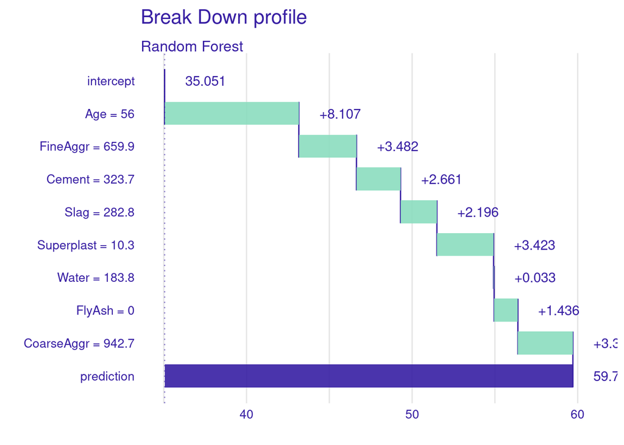

```r
plot(bdown_rf_highest)
```

## c) Explain the predictions using LIME:

```r
(lime_rf_lowest <- predict_surrogate(explainer = explainer_rf,
                  new_observation = lowestStrength[,-9],
                  type = "localModel"))
```

```
##    estimated              variable original_variable dev_ratio response
## 1  35.051096          (Model mean)                   0.5029192
## 2  46.900900           (Intercept)                   0.5029192
## 3 -11.355929         Cement <= 255            Cement 0.5029192
## 4   0.281747 81.3 < Slag <= 105.77              Slag 0.5029192
## 5   1.294099       FlyAsh <= 94.51            FlyAsh 0.5029192
## 6  -8.860744        Water > 175.57             Water 0.5029192
##   predicted_value         model
## 1        10.45898 Random Forest
## 2        10.45898 Random Forest
## 3        10.45898 Random Forest
## 4        10.45898 Random Forest
## 5        10.45898 Random Forest
## 6        10.45898 Random Forest
```

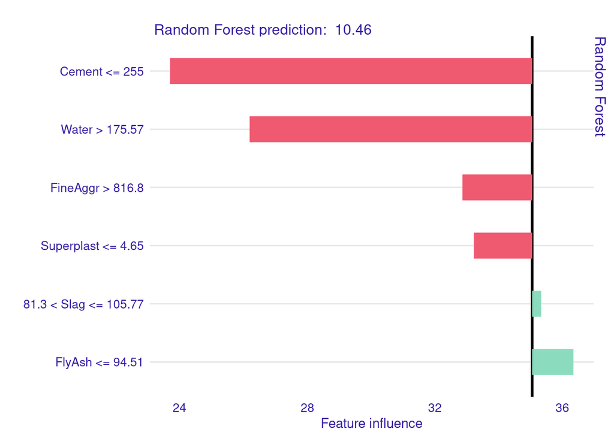

```r
plot(lime_rf_lowest)
```

Here we can see the LIME plot for the lowest strength cement. We can see that the condition that makes the prediction reduce the most is Cement under the 255.5, the we see that the water content over 175.5 also contributes in reducing the cement strength. Then lower that 4.65 superplast content and over 816.8 FineAggr content also reduce a the strength of the cement lastly we can see that FlyAsh under 94 and Slag between 81,3 and 105.77 contribute positively. So in conclusion we can see that concrete with low cement by a lot of water reduce the most the concrete strenght.

```r
(lime_rf_highest <- predict_surrogate(explainer = explainer_rf,
                  new_observation = highestStrength[,-9],
                  type = "localModel"))
```

```
##    estimated                  variable original_variable dev_ratio response
## 1 35.0510956              (Model mean)                   0.2199676
## 2 32.6793275               (Intercept)                   0.2199676
## 3  2.7061014 298.04 < Cement <= 324.26            Cement 0.2199676
## 4  2.7711082             Slag > 168.47              Slag 0.2199676
## 5  0.1277231            FlyAsh <= 91.3            FlyAsh 0.2199676
## 6 -0.6361293     182.41 < Water <= 191             Water 0.2199676
##   predicted_value         model
## 1        59.71046 Random Forest
## 2        59.71046 Random Forest
## 3        59.71046 Random Forest
## 4        59.71046 Random Forest
## 5        59.71046 Random Forest
## 6        59.71046 Random Forest
```

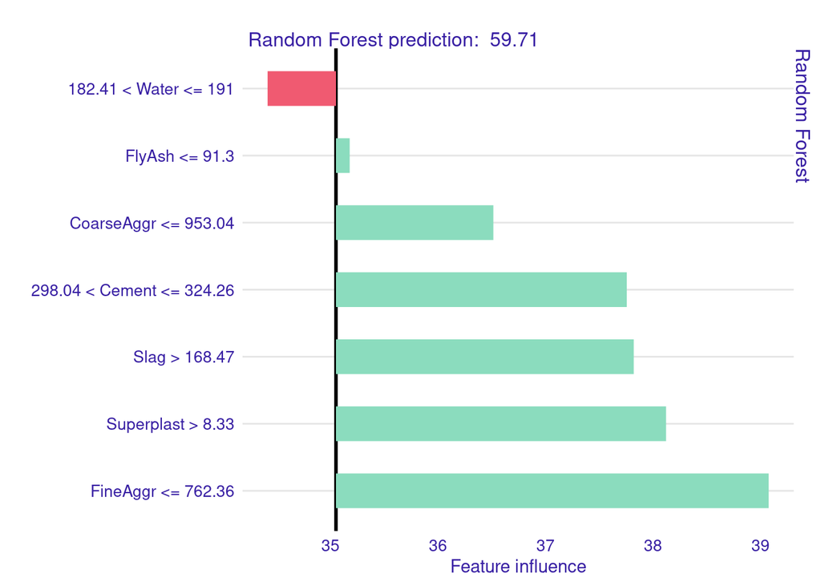

```r
plot(lime_rf_highest)
```

Next looking at the highest concrete strength lime plot, we can see that the most influential feature is having the FIneAggr under 762.36, followed by having the superplast over 8.33. It is interesting to observe that cement is not the most influential parameter but only the fourth.

## d) Do individual conditional expectation (ICE) plot, or ceteris paribus plot:

```r
(cp_rf_lowest <- predict_profile(explainer = explainer_rf,
                           new_observation = lowestStrength))
```

```
## Top profiles    :
##       Cement Slag FlyAsh Water Superplast CoarseAggr FineAggr Age   _yhat_
## 669   102.00  102      0   192          0        888    943.1   3 8.926460
## 669.1 106.38  102      0   192          0        888    943.1   3 9.165367
## 669.2 110.76  102      0   192          0        888    943.1   3 9.278412
## 669.3 115.14  102      0   192          0        888    943.1   3 9.481063
## 669.4 119.52  102      0   192          0        888    943.1   3 9.584609
## 669.5 123.90  102      0   192          0        888    943.1   3 9.808746
##       _vname_ _ids_       _label_
## 669    Cement   669 Random Forest
## 669.1  Cement   669 Random Forest
## 669.2  Cement   669 Random Forest
## 669.3  Cement   669 Random Forest
## 669.4  Cement   669 Random Forest
## 669.5  Cement   669 Random Forest
##
##
## Top observations:
##     Cement Slag FlyAsh Water Superplast CoarseAggr FineAggr Age   _yhat_
## 669    153  102      0   192          0        888    943.1   3 10.45898
##           _label_ _ids_
## 669 Random Forest     1
```

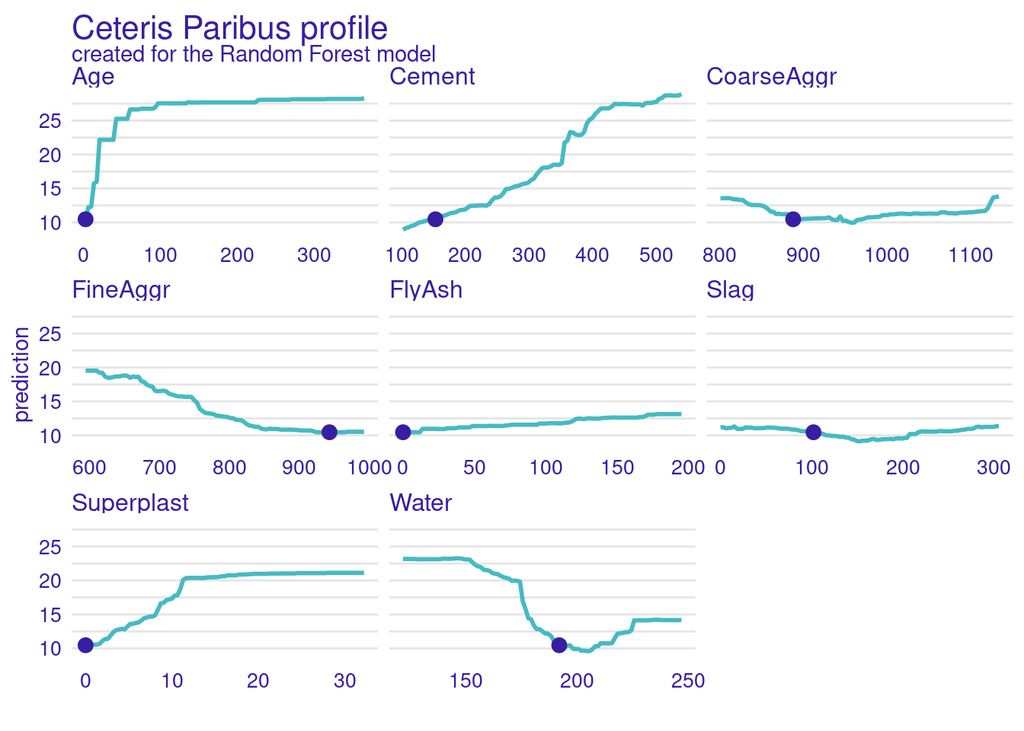

```r
plot(cp_rf_lowest)
```

```r
(cp_rf_highest <- predict_profile(explainer = explainer_rf,
                           new_observation = highestStrength))
```

```
## Top profiles    :
##       Cement  Slag FlyAsh Water Superplast CoarseAggr FineAggr Age   _yhat_
## 154   102.00 282.8      0 183.8       10.3      942.7    659.9  56 42.22337
## 154.1 106.38 282.8      0 183.8       10.3      942.7    659.9  56 42.56742
## 154.2 110.76 282.8      0 183.8       10.3      942.7    659.9  56 42.56742
## 154.3 115.14 282.8      0 183.8       10.3      942.7    659.9  56 42.86160
## 154.4 119.52 282.8      0 183.8       10.3      942.7    659.9  56 42.88128
## 154.5 123.90 282.8      0 183.8       10.3      942.7    659.9  56 42.88128
##       _vname_ _ids_       _label_
## 154    Cement   154 Random Forest
## 154.1  Cement   154 Random Forest
## 154.2  Cement   154 Random Forest
## 154.3  Cement   154 Random Forest
## 154.4  Cement   154 Random Forest
## 154.5  Cement   154 Random Forest
##
##
## Top observations:
##     Cement  Slag FlyAsh Water Superplast CoarseAggr FineAggr Age   _yhat_
## 154  323.7 282.8      0 183.8       10.3      942.7    659.9  56 59.71046
##           _label_ _ids_
## 154 Random Forest     1
```

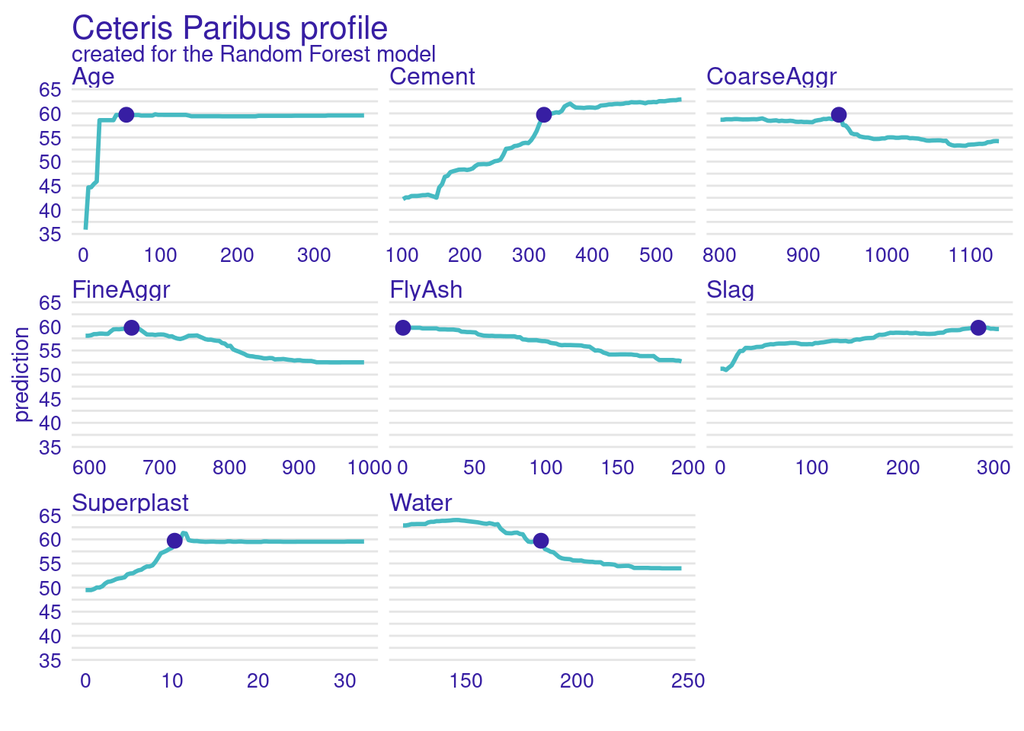

```r
plot(cp_rf_highest)
```

## e) Plot the ICE plot for variable age for each case in the test sample. Add the global Partial Dependence Plot:

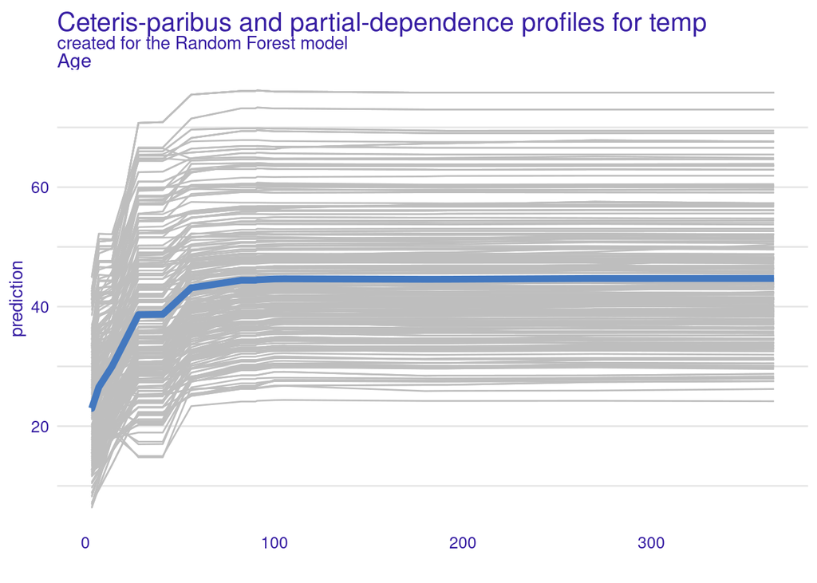

```r
mp_rf <- variable_profile(explainer = explainer_rf,
  variables = "Age",
  N = 330,
  type = "partial"
)

plot(mp_rf, geom = "profiles") +
  ggtitle("Ceteris-paribus and partial-dependence profiles for temp")
```

On the partial dependence plot we can observe that the strength prediction increases we the age increases between 0 and 100. Past the age of 100, the prediction are constant at their maximum. The partial dependence plot appears to be near to the center of the ICE plots.